# MAD – Data Analysis & Biostatistics in R

Chapter 1 - Introduction and Installation of R

James R. Hunter, Ph.D.

2020-09-02

[figure not shown]

# Preface

Over the following chapters, we will learn a bit about the analysis of the data we collect and study. We will learn to manipulate the data to make it ready for analysis and to gain insights into our data with biostatistics and machine learning methods. Our primary tool to accomplish this will be the statistical and programming language, R.

We will adopt a very practical approach. We will not emphasize abstract mathematics. Rather we will set up a number of problems coming from medical, microbiological and other areas of research and develop the knowledge necessary to solve them. At the conclusion of the course, you will have had many opportunities to apply the techniques we will develop to problems that interest you.

Let me emphasize that all the course material, including this course notebook and the presentation slides, are being prepared from within the RStudio environment, using the *R Markdown* format. R, together with RStudio, has a very wide range of resources. This course will only be able to scratch the surface of what the combination can do.

When the chapters include R programming, I will use the following typeface (font).

```
    sub_data <- data %>%
      select(day20:day25)
    glimpse(sub_data)
    summary(sub_data)
    sub_data %>% map_dbl(sd)
```

At times, there will be an important point that doesn’t fit cleanly in the flow of the text, but is important to understand. I call this type of point a **VSS**, a *verbum sapientibus satis*, Latin for “a word to the wise is sufficient” in honor of Ms. Walden, my first Latin teacher in junior high school.

# History of R and Why We Need It

## History

Bell Labs, the former research arm of ATT in New Jersey (now owned by Nokia), was a rich source of computer languages. C and its derivatives come from there. S, a Bell Labs product of the 1970s and 1980s is a language that allowed scientists to solve statistical problems without having to write their own code for the procedures, as they would have had to do in Fortran, Cobol, Pascal or C. When ATT divested itself of Bell Labs, in the 1980s, S became a commercial product and still exists.

R has a very active user community. Developers and end users have contributed more than 15,000 packages with functions and datasets that cover more academic and professional subjects that we can imagine. They range from quantitative financial analysis to astrophysics to microbiology. R has become one of the most important computer languages over the last decade, especially in the academic arena.

In universities and research institutions around the world, R is the most popular analytic research tool in use. Its presence in businesses is growing as well. In medicine, biology and microbiology, R has very important resources that come from the CRAN ecosystem and from a specialized system called Bioconductor. This latter effort has produced some 1,800 additional packages that deal with almost every important type of genomic analysis that we need for projects in biology and medicine.

One of the reasons for the strong growth of R is that it remains *open-source*. As such, you can acquire it without cost. **It’s Free!**

## Why Does Professor Hunter Use R

I have a long history with programs such as SPSS, Stata, SAS, Excel and even Graphpad Prism. I began using SPSS when you still loaded your card decks with commands and data into an IBM 360 computer. (I’m speaking of the late 1960s and early 1970s.) Since then, I’ve used various versions of all of the above programs, but I was always dissatisfied. In 2011, I discovered R and understood that my dissatisfaction had a solution. The great advantage of R over the other programs is that you can completely control the sequence of operations in your analysis. You write a program (a *script*) and R will execute exactly what you have ordered it to do. The next day, it will produce exactly the same result as the day before when you re-run the script. You won’t have to worry about what options in a dialog box you may have selected.

## Problems with the Traditional Data Analysis Programs

With all their dialog boxes and menus, the “canned” analysis programs keep you away from the details and steps of an analysis and from the intermediate results of data cleaning operations. Worse, if you do not click on exactly the same options in the same order on Tuesday that you did on Monday, the program will produce a different result. Still worse, these dialog boxes offer many options that are highly advanced and that most biologists and non-statistician researchers do not understand. As a result, the results they produce don’t make sense and can’t be explained. After all, most researchers do not understand highly sophisticated statistical reasoning, nor should they.

As Prof. Sacha Eskamp of the University of Amsterdam explained:

> *You can only do what the buttons say you can do.* [^1]

## Software – *Open-Source* vs. Comercial

As a final problem with these big programs I will discuss here, their cost is absurdly high for graduate students and for research institutions. Even the student editions of these programs are frequently beyond the means of a student. As a result, students typically make unauthorized (“cracked”) copies to access the programs. In an era when we are discussing improving the ethics of science and business, how does a student justify a career based on using stolen software?

Decades ago, *open-source* programs were typically of very low quality. However, no more. There exist *open-source* equivalents to the paid software programs in almost all areas for which we need programs. The world of *open-source* software has really changed the way we can do research.

## R vs. Python

An alternative to R that has a somewhat similar concept for the programming of analyses is the *Python* language. Launched in 1991 by Guido van Rossum of the Netherlands, Python took the name of the English comedy group, “Monty Python’s Flying Circus”, not the snake species. Python is a high-level interpreted language, exactly like R. However, Python was designed as a general language in contrast to the statistical focus of R. To execute even basic statistics in Python requires learning the commands of various modules, such as Pandas and Numpy, which are necessary to load and analyze data sets in Python.

## Learning R is very Difficult?

Learning the basics of R is easy. This includes learning to specify vectors and data frames and execute statistical and mathematical functions. Even in the first class, we will manage to execute various Monte Carlo simulations.[^2] This is a task that requires the skill of building and specifying data and carrying out an analysis.

Thus, in the initial phases of learning R, you will not suffer much. Later on, when you want to make use of more advanced packages and functions (e.g., Bioconductor), you will need to focus quite intensely to program them correctly. However, we will only approach these at the end of the course.

```
    set.seed(1)
    dados <- runif(100, min = 0, max = 1000)
    media <- mean(dados)
```

This example will work. (The result is 517.847.) When you install R, you can execute these commands. However, the point here is to show you that the code needs to written exactly as the program demands. As you’ve probably heard before: “*a computer is a big, dumb adding machine*”. It does exactly what you command it to do – and **nothing else**.

## Important Notice

It will be necessary for you to invest some time in the course between classes. First, you will need to install the software (R and RStudio) on your laptops to be able to do the class exercises and homework. Second, you will need to read the material that I will be suggesting here and in class. And third, I recommend you try out one of the basic R courses on the internet so that you get a second approach to the same topics we will be covering in our course.

# Task 1 - Install the Software

## Installation of R

You can find R on the following site:

> https://cran.r-project.org/

As I suggested before, CRAN is the official group that maintains R and guarantees that all the components function alone and as a group. This high level of quality and consistency is one of the reasons that R is turning popular. The figure below shows the initial screen of R.

[figure not shown]

CRAN Initial Screen

Verify that the version on your browser is 4.0.2 (or higher). This version has the code name “Taking Off Again”.

Versions of R exist for Windows, MacOS and for various flavors of Linux. In the upper part of the screen, click on the appropriate link for your operating system and follow the instructions to download the software. I will outline here some of the steps for Windows and MacOS.

### Installation of R for Windows

1. Click on the link “Download R for Windows”
2. On the next screen, click on “base”

[figure not shown]

R Windows

3. Click on the link: “Download R 4.0.2 for Windows”

The site will download the program on your computer in the normal way for your operating system. As part of the normal installation, R will place an icon on your desktop.

### Installation of RStudio

Why do we need this program? RStudio gives R wings. At a basic level, RStudio provides our interface to R in the Console. It is also based on a text editor in which you can develop the scripts that you will run in R. You can best think of RStudio as the jackknife for R. You can manage files, control versions of your scripts, set up projects that keep all the files for a given task together and see your results in both reports and graphics. I will be using RStudio in all the classes of the course to control program demonstrations. All the documentation for this course have been developed in RStudio. Like R, RStudio is **free**. There exist commercial versions of various RStudio products but you don’t need them.

To install RStudio, navigate directly to the following page: https://www.rstudio.com/products/rstudio/download/. This will allow you avoid a lot of unnecessary commercials for their paid products.

This screen has a lot of information. You need to scroll down to a big, blue button that says, “Download RStudio for Windows” and gives the version number and size of the program. It appears similar to the following figure:

[figure not shown]

RStudio Installation

If you need additional help with the installation, I’ve put a video on my YouTube channel entitled “MAD CD Instalar R”. To reach the channel, go to: https://www.youtube.com/channel/UCbvgZ8RYeTtgjhAKE-jub5A

## Starting RStudio

On your Desktop or through your menus, double click on the icon for RStudio (not the icon for R) . RStudio will open and R will automatically open within RStudio. In one of the panels (normally the panel on the left) will appear the *Console*. This is where R executes its functions.

On the right side of the screen will be two panels. In the upper panel, you will see various tabs. The two most important for now are the *Environment* (This shows variables that R its active memory.) and *History* (a list of commands already executed so you don’t have to retype them).

In the lower panel, there are five tabs. *Files* shows a directory of files in the *working directory* or other directory that you choose. *Plots* shows graphics that you create. *Packages* shows a list of all the R packages that you have installed on your machine. *Help* is a comprehensive library of all the help pages for the commands and functions that are available to you. *Viewer* is a mini-browser that shows reports with a high graphic content similar to web pages.

At startup, the Console will show the current version of R and provide the first caret prompt to let you know that it is loaded and ready.

[figure not shown]

RStudio Initial Screen

## Install the Packages We Need

During the course, we will use various packages with additional functions that are not included in the standard initial download (“*Base R*”). I have prepared a script that will install packages that we will use and some that are also important adjuncts to a useful R installation. Working with this script will permit you to start learning how to use R. The script has the name: `initial_packages.r`.

```r
packages <- c("tidyverse", "broom", "car", "caret", "corrr", "data.table",
              "descr", "devtools", "gapminder", "ggpubr", "ggvis", "ggsci",
              "glue", "gmodels", "gt", "here", "Hmisc", "hms", "janitor",
              "jsonlite", "kableExtra","knitr", "lattice", "lubridate",
              "magrittr", "mice", "nortest", "nycflights13",
              "outliers", "palmerpenguins", "pROC", "psych", "RColorBrewer",
              "Rcpp", "readxl", "ROCR", "shiny", "styler", "summarytools",
              "titanic", "triangle", "usethis")

#install.packages(packages)
```

### Your First Program

In this first script, I used two important commands in R. I want to assign the name `packages` to the list of the 42 packages. I don’t want to have to repeat the command 42 times, once for each package. Boring. Rather, I want R to do the work. So I use the *assignment operator* “`<-`” to attribute everything on the right side of the expression to the word `packages`. The assignment operator consists of the left caret(Less than) symbol “<” followed by the hyphen “-”.

**VSS** The assignment operator is not the same as the equals sign “=”. However, R allows you to use “=” for assignment. Yes, this is confusing, but so many programmers come from an environment in which “=” means assignment that R permits it. Equality in R is a logical condition in which two values are (or are not) equal to each other. This uses a symbol composed of two equal signs (`==`).

My advice is to use the “`<-`” sign for assignment and not the “=”. Some day you will confuse the two meanings of “=”. We all do it. Develop the habit early of using “`<-`” for assignment and you can avoid this error.

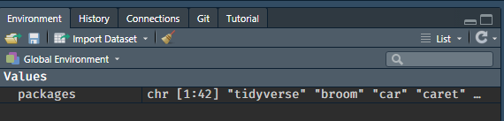

packages Vector

The second line of the script does the work. `install.packages(packages)` does exactly that. It goes out to CRAN’s server, downloads each package in the vector and installs it on your system.[^3]

## Where Do I Find `inital_packages.r`?

An important resource that we will be using in this course is *GitHub*. It is the public face of a version control system called *git*. Git allows you to maintain all the changes you make to your scripts on your computer and on the remote site GitHub. This means that you can return to a previous version of a line in a script if you discover errors in more recent versions. We will primarily be using the repository (mini-site) for the course on GitHub as a storage site for the course’s files.

The “repo” (how people normally refer to the repositories) for our course is: https://github.com/jameshunterbr/MAD-Infecto-2020

[figure not shown]

GitHub Repo

### Downloading `initial_packages.r`

When you are in the repo, click on the file name. The file text will now appear. Next, you need to click on the **Raw** button. Finally, “right click” on the file on the next screen and save the file to your R directory with the **Save Page (As) …** command on the pop-up menu.

### Install the Packages

The final step in this initial foray into R is to load the program into RStudio and execute it. If you go the *Files* tab on the right side of the RStudio screen, you will find `initial_packages.r`. Click on it and the program will open in the left upper part of your screen.

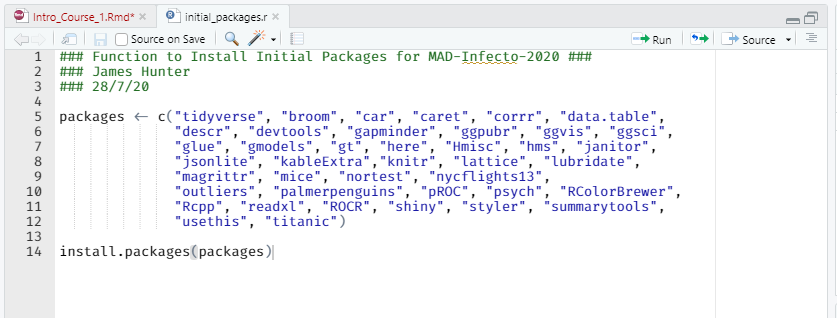

RStudio Program Pane

To execute the program, click on the word *Source* in the bar above the program. You will be able to follow what the program is doing in the *Console* panel. It will add the programs specified in the list and a number of other packages that the ones specified need to operate.

# Conclusion

You have now got R and RStudio operating and ready to carry out data analysis tasks that you want. You’ve executed a program. Next, we will look at some resources that assist in making R more comprehensible and easier to operate.

# But First, A Philosophical Moment

> “We are drowning in information, but we are starved for knowledge”. – John Naisbitt[^4]

Why do medicine and biology need statistics and data analysis? In medical science, the organisms we study are generally too small to be seen. Bacteria, viruses, human, animal and plant cells are too small. Even more dramatically, the machines we use to explore genetic sequences, machines that determine the frequency and location of individual nucleotides are probabilistic. “Calling bases” as a phrase, which is what the software related to sequencing does, suggests that the there can be errors. As well, the natural process of genetic replication is fraught with errors and many genomes, especially smaller genomes like those of viruses don’t have editing mechanisms to correct errors. What all this natural uncertainty means as a practical matter is that we need probabilistic means to find the underlying truth in the phenomena we study.

Also, at a clinical level, humans react to drugs, treatments, surgeries or other interventions very differently. However, we need to come to some way to sort out all these individual differences (what we call variability in statistics) to find an underlying truth.

And, that’s what statistics helps us to do. With it, we develop a set of rules and find conclusions that turns the welter of information we deal with into knowledge. While you may rely on a statistics or quantitative methods specialist to undertake advanced models and analyses you are expected, as graduate students, to be able to create at least basic analyses yourselves. And, certainly, you are expected as scientists to understand the statistics you read in papers and books, separate the wheat from the chaff, and be able to “call Bullshit”[^5] when someone is trying to deceive you.

[^1]: Baker, Monya, “Code Alert”, **Nature**, Vol 541, 26/1/2017, p. 563 - 565.
[^2]: Irizzary, Rafael, **Introduction to Data Science**, (https://rafalab.github.io/dsbook), Ch. 26.3.
[^3]: The line is currently *commented out*. The hashtag (’#“) sign at the front of the line means that R will ignore anything after the”#". In the live version of the file, the comment character is removed.
[^4]: Although most frequently ascribed to futurologist John Naisbitt, this quote has many fathers and mothers. Taken here from Danielle Navarro, **Learning statistics with R: A tutorial for psychology students and other beginners**, 2020, http://compcogscisydney.org/learning-statistics-with-r
[^5]: CT Bergstrom & JD West, **Calling bullshit: the art of skepticism in a data-driven world**, New York: Random House, 2020.